# Seasonal Agriculture Performance Analysis

**VOIS AICTE Batch 1 · 2026-2027 — Major Project**

| **Student** | Pulkit Chopra |
| --- | --- |
| **College** | Maharaja Agrasen Institute of Management Studies |
| **AICTE Student ID** | STU6a0fa9ea7ddf11779411434 |
| **Course** | Data Visualization |

## Problem Statement

Agricultural activities are influenced by seasonal variations in environmental conditions, farming practices, resource availability and market conditions. As a result, agricultural performance may differ from one season to another. However, raw agricultural data does not clearly explain *how* performance changes across seasons, or what patterns can be observed in different seasonal conditions.

This project analyses a 4,000-farm agricultural dataset to investigate seasonal differences in agricultural performance by identifying meaningful patterns, trends, relationships and variations within the available data.

## Analytical Questions

1. Are the three seasons — Kharif, Rabi and Zaid — genuinely different in environmental terms?
2. Does crop yield vary across seasons, and is that variation statistically significant?
3. How does economic performance (cost, revenue, profit) change from season to season?
4. Does disease and pest pressure follow a seasonal pattern, and what drives it?
5. Does the effectiveness of an irrigation method depend on the season?
6. Are seasonal patterns consistent across states, or are some regions insulated?
7. Are there unexpected or counter-intuitive seasonal patterns in the data?

## 1. Setup and Data Loading

```python
import pandas as pd
import numpy as np
import matplotlib.pyplot as plt
import seaborn as sns
from scipy import stats

pd.set_option('display.width', 200)
pd.set_option('display.max_columns', 40)

plt.rcParams.update({
    'figure.dpi': 110,
    'axes.grid': True,
    'grid.alpha': 0.25,
    'axes.spines.top': False,
    'axes.spines.right': False,
})

SEASON_COLORS = {'Kharif': '#2C5F2D', 'Rabi': '#97BC62', 'Zaid': '#B85042'}
SEASON_ORDER  = ['Kharif', 'Rabi', 'Zaid']

print('Libraries loaded.')
```

```
Libraries loaded.
```

```python
df = pd.read_csv('agriculture_dataset.csv')

print(f'Rows:    {df.shape[0]:,}')
print(f'Columns: {df.shape[1]}')
df.head()
```

```
Rows:    4,000
Columns: 28
```

|  | Farm_ID | State | District | Crop | Season | Farm_Area_Hectares | Rainfall_mm | Avg_Temperature_C | Humidity_pct | Sunlight_Hours | Soil_pH | Soil_Moisture_pct | Nitrogen_kg_ha | Phosphorus_kg_ha | Potassium_kg_ha | Irrigation_Method | Fertilizer_kg_ha | Pesticide_Litre_ha | Seed_Quality_Score | Yield_Tonnes_Hectare | Production_Tonnes | Market_Price_INR | Total_Cost_INR | Revenue_INR | Profit_INR | Water_Used_m3 | Water_Efficiency | Disease_Pest_Risk_pct |
| --- | --- | --- | --- | --- | --- | --- | --- | --- | --- | --- | --- | --- | --- | --- | --- | --- | --- | --- | --- | --- | --- | --- | --- | --- | --- | --- | --- | --- |
| 0 | SF10001 | Andhra Pradesh | Rajkot | Wheat | Kharif | 0.53 | 486.4 | 24.3 | 69.1 | 5.8 | 7.14 | 32.8 | 75.8 | 61.3 | 91.0 | Drip | 242.7 | 4.33 | 0.76 | 2.46 | 1.30 | 23700 | 42662 | 30810 | -11852 | 237 | 5.485 | 55.3 |
| 1 | SF10002 | Maharashtra | Nalgonda | Maize | Kharif | 6.53 | 855.4 | 25.7 | 78.4 | 5.1 | 5.20 | 32.0 | 82.1 | 35.4 | 121.8 | Flood | 271.4 | 6.86 | 0.94 | 0.30 | 1.96 | 20613 | 492351 | 40401 | -451950 | 4953 | 0.396 | 49.9 |
| 2 | SF10003 | Telangana | Warangal | Pulses | Rabi | 4.86 | 455.6 | 23.9 | 56.4 | 10.3 | 5.82 | 8.1 | 118.5 | 51.5 | 117.9 | Drip | 162.6 | 6.08 | 0.98 | 0.52 | 2.53 | 75283 | 315210 | 190466 | -124744 | 1275 | 1.984 | 33.7 |
| 3 | SF10004 | Telangana | Indore | Rice | Kharif | 4.50 | 753.2 | 29.7 | 65.2 | 6.3 | 5.98 | 23.7 | 138.6 | 55.6 | 115.5 | Rainfed | 182.2 | 6.39 | 0.74 | 1.84 | 8.28 | 24244 | 296444 | 200740 | -95704 | 3834 | 2.160 | 50.6 |
| 4 | SF10005 | Karnataka | Ludhiana | Maize | Zaid | 4.21 | 101.6 | 34.1 | 55.2 | 6.5 | 6.90 | 29.3 | 124.1 | 69.0 | 121.4 | Flood | 244.9 | 7.61 | 0.90 | 2.21 | 9.30 | 20818 | 337959 | 193607 | -144352 | 3287 | 2.829 | 32.3 |

```python
df.info()
```

```
<class 'pandas.DataFrame'>
RangeIndex: 4000 entries, 0 to 3999
Data columns (total 28 columns):
 #   Column                 Non-Null Count  Dtype
---  ------                 --------------  -----
 0   Farm_ID                4000 non-null   str
 1   State                  4000 non-null   str
 2   District               4000 non-null   str
 3   Crop                   4000 non-null   str
 4   Season                 4000 non-null   str
 5   Farm_Area_Hectares     4000 non-null   float64
 6   Rainfall_mm            3952 non-null   float64
 7   Avg_Temperature_C      4000 non-null   float64
 8   Humidity_pct           4000 non-null   float64
 9   Sunlight_Hours         4000 non-null   float64
```

[output cut: 20 more lines]

### Understanding the columns

The dataset records one row per farm and covers five broad areas:

| Group | Columns |
| --- | --- |
| **Identity & location** | `Farm_ID`, `State`, `District` |
| **Farming context** | `Crop`, `Season`, `Farm_Area_Hectares`, `Irrigation_Method` |
| **Environment** | `Rainfall_mm`, `Avg_Temperature_C`, `Humidity_pct`, `Sunlight_Hours`, `Soil_pH`, `Soil_Moisture_pct` |
| **Inputs** | `Nitrogen_kg_ha`, `Phosphorus_kg_ha`, `Potassium_kg_ha`, `Fertilizer_kg_ha`, `Pesticide_Litre_ha`, `Seed_Quality_Score`, `Water_Used_m3` |
| **Outcomes** | `Yield_Tonnes_Hectare`, `Production_Tonnes`, `Market_Price_INR`, `Total_Cost_INR`, `Revenue_INR`, `Profit_INR`, `Water_Efficiency`, `Disease_Pest_Risk_pct` |

```python
for col in ['State', 'District', 'Crop', 'Season', 'Irrigation_Method']:
    print(f'{col:20s} ({df[col].nunique()} unique)')
    print('  ', ', '.join(sorted(df[col].unique())))
    print()
```

```
State                (8 unique)
   Andhra Pradesh, Gujarat, Karnataka, Madhya Pradesh, Maharashtra, Punjab, Tamil Nadu, Telangana

District             (10 unique)
   Erode, Guntur, Indore, Krishna, Ludhiana, Nalgonda, Nashik, Raichur, Rajkot, Warangal

Crop                 (8 unique)
   Chilli, Cotton, Groundnut, Maize, Pulses, Rice, Sugarcane, Wheat

Season               (3 unique)
   Kharif, Rabi, Zaid

Irrigation_Method    (4 unique)
   Drip, Flood, Rainfed, Sprinkler
```

```python
df.describe().T.round(2)
```

|  | count | mean | std | min | 25% | 50% | 75% | max |
| --- | --- | --- | --- | --- | --- | --- | --- | --- |
| Farm_Area_Hectares | 4000.0 | 7.89 | 4.22 | 0.50 | 4.26 | 7.90 | 11.65 | 15.00 |
| Rainfall_mm | 3952.0 | 601.15 | 288.93 | 80.00 | 370.20 | 582.00 | 834.95 | 1395.20 |
| Avg_Temperature_C | 4000.0 | 26.82 | 3.82 | 16.20 | 23.90 | 26.90 | 29.60 | 39.70 |
| Humidity_pct | 4000.0 | 63.21 | 11.96 | 25.00 | 54.78 | 63.00 | 71.90 | 95.00 |
| Sunlight_Hours | 4000.0 | 7.32 | 1.12 | 3.50 | 6.60 | 7.30 | 8.10 | 11.00 |
| Soil_pH | 4000.0 | 6.70 | 0.64 | 5.20 | 6.26 | 6.69 | 7.14 | 8.40 |
| Soil_Moisture_pct | 3960.0 | 26.51 | 6.71 | 8.00 | 21.70 | 26.40 | 31.30 | 47.00 |
| Nitrogen_kg_ha | 4000.0 | 120.25 | 31.22 | 40.00 | 98.50 | 120.10 | 141.22 | 220.00 |
| Phosphorus_kg_ha | 4000.0 | 57.78 | 17.02 | 15.00 | 46.20 | 57.50 | 69.40 | 120.00 |
| Potassium_kg_ha | 4000.0 | 104.76 | 27.74 | 30.00 | 86.20 | 105.10 | 123.60 | 200.00 |
| Fertilizer_kg_ha | 4000.0 | 186.04 | 60.26 | 40.00 | 143.98 | 186.25 | 227.20 | 400.00 |
| Pesticide_Litre_ha | 4000.0 | 5.07 | 1.98 | 0.50 | 3.69 | 5.12 | 6.40 | 12.08 |
| Seed_Quality_Score | 4000.0 | 0.83 | 0.10 | 0.65 | 0.74 | 0.83 | 0.91 | 1.00 |
| Yield_Tonnes_Hectare | 3968.0 | 5.27 | 13.36 | 0.30 | 1.05 | 1.74 | 2.84 | 101.44 |
| Production_Tonnes | 4000.0 | 43.25 | 126.88 | 0.15 | 5.02 | 11.77 | 24.36 | 1424.40 |
| Market_Price_INR | 4000.0 | 44714.17 | 30266.16 | 2594.00 | 21429.25 | 25913.00 | 68279.00 | 131240.00 |
| Total_Cost_INR | 4000.0 | 526303.58 | 294419.14 | 26826.00 | 274577.50 | 519082.50 | 761996.50 | 1349990.00 |
| Revenue_INR | 4000.0 | 637860.05 | 636974.71 | 6107.00 | 207517.25 | 456830.50 | 836874.75 | 5080900.00 |
| Profit_INR | 4000.0 | 111556.46 | 545081.89 | -1019223.00 | -148731.75 | 3673.00 | 216187.75 | 4345421.00 |
| Water_Used_m3 | 4000.0 | 6045.57 | 5572.94 | 128.00 | 2268.75 | 4435.00 | 7829.75 | 40902.00 |
| Water_Efficiency | 4000.0 | 5.39 | 8.84 | 0.14 | 1.66 | 2.94 | 5.15 | 79.80 |
| Disease_Pest_Risk_pct | 4000.0 | 46.37 | 12.42 | 5.00 | 37.30 | 46.40 | 54.90 | 88.90 |

## 2. Data Cleaning and Preparation

Three checks before any analysis: duplicates, missing values, and impossible values.

```python
print('Duplicate Farm_IDs:', df['Farm_ID'].duplicated().sum())
print('Fully duplicated rows:', df.duplicated().sum())

missing = df.isna().sum()
missing = missing[missing > 0]
print('\nColumns with missing values:')
print(pd.DataFrame({
    'missing': missing,
    'pct': (missing / len(df) * 100).round(2)
}))
```

```
Duplicate Farm_IDs: 0
Fully duplicated rows: 0

Columns with missing values:
                      missing  pct
Rainfall_mm                48  1.2
Soil_Moisture_pct          40  1.0
Yield_Tonnes_Hectare       32  0.8
```

Three columns have missing values, each under 1.5% of rows. Dropping those rows would throw away otherwise complete records, so instead each gap is filled with the **median of its own crop-and-season group**. A missing rainfall figure for a Kharif rice farm is replaced by the median rainfall of Kharif rice farms — not the global median, which would flatten exactly the seasonal signal this project is trying to measure.

The median is used rather than the mean because these columns are skewed and a few extreme farms would drag a mean fill upwards.

```python
df_clean = df.copy()

fill_cols = ['Rainfall_mm', 'Soil_Moisture_pct', 'Yield_Tonnes_Hectare']

for col in fill_cols:
    before = df_clean[col].isna().sum()
    df_clean[col] = (df_clean
                     .groupby(['Crop', 'Season'])[col]
                     .transform(lambda s: s.fillna(s.median())))
    after = df_clean[col].isna().sum()
    print(f'{col:22s}  {before:3d} missing -> {after} missing')

print('\nTotal missing values remaining:', df_clean.isna().sum().sum())
```

```
Rainfall_mm              48 missing -> 0 missing
Soil_Moisture_pct        40 missing -> 0 missing
```

```
Yield_Tonnes_Hectare     32 missing -> 0 missing

Total missing values remaining: 0
```

```python
# Sanity checks: values that would be physically impossible
checks = {
    'Negative farm area':      (df_clean.Farm_Area_Hectares <= 0).sum(),
    'Negative rainfall':       (df_clean.Rainfall_mm < 0).sum(),
    'Soil pH outside 0-14':    ((df_clean.Soil_pH < 0) | (df_clean.Soil_pH > 14)).sum(),
    'Humidity outside 0-100':  ((df_clean.Humidity_pct < 0) | (df_clean.Humidity_pct > 100)).sum(),
    'Negative revenue':        (df_clean.Revenue_INR < 0).sum(),
    'Negative water used':     (df_clean.Water_Used_m3 < 0).sum(),
}
for name, count in checks.items():
    print(f'{name:26s} {count}')
```

```
Negative farm area         0
Negative rainfall          0
Soil pH outside 0-14       0
Humidity outside 0-100     0
Negative revenue           0
Negative water used        0
```

### Feature engineering

Two derived columns make the economic comparison fair and simple:

- **`Profit_per_Hectare`** — raw `Profit_INR` is dominated by farm size, so a large low-performing farm can outrank a small excellent one. Dividing by area removes that.
- **`Is_Profitable`** — a boolean flag, so the share of farms that broke even can be compared alongside the average.

```python
df_clean['Profit_per_Hectare'] = df_clean['Profit_INR'] / df_clean['Farm_Area_Hectares']
df_clean['Is_Profitable']      = df_clean['Profit_INR'] > 0

df_clean['Season'] = pd.Categorical(df_clean['Season'],
                                    categories=SEASON_ORDER, ordered=True)

print('Rows after cleaning:', len(df_clean))
df_clean[['Season', 'Crop', 'Yield_Tonnes_Hectare',
          'Profit_per_Hectare', 'Is_Profitable']].head()
```

```
Rows after cleaning: 4000
```

|  | Season | Crop | Yield_Tonnes_Hectare | Profit_per_Hectare | Is_Profitable |
| --- | --- | --- | --- | --- | --- |
| 0 | Kharif | Wheat | 2.46 | -22362.264151 | False |
| 1 | Kharif | Maize | 0.30 | -69211.332312 | False |
| 2 | Rabi | Pulses | 0.52 | -25667.489712 | False |
| 3 | Kharif | Rice | 1.84 | -21267.555556 | False |
| 4 | Zaid | Maize | 2.21 | -34287.885986 | False |

## 3. Exploratory Analysis — How the Seasons Differ

### 3.1 Season distribution

```
        farms  share_pct
Season
Kharif   1779       44.5
Rabi     1627       40.7
Zaid      594       14.8
```

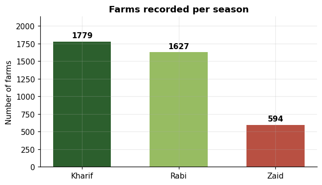

```python
counts = df_clean['Season'].value_counts().reindex(SEASON_ORDER)
pct = (counts / len(df_clean) * 100).round(1)
print(pd.DataFrame({'farms': counts, 'share_pct': pct}))

fig, ax = plt.subplots(figsize=(6, 3.5))
bars = ax.bar(SEASON_ORDER, counts.values,
              color=[SEASON_COLORS[s] for s in SEASON_ORDER], width=0.6)
ax.bar_label(bars, fmt='%d', padding=3, fontweight='bold')
ax.set_ylabel('Number of farms')
ax.set_title('Farms recorded per season', fontweight='bold')
ax.set_ylim(0, counts.max() * 1.2)
plt.tight_layout()
plt.show()
```

Kharif and Rabi dominate the dataset; Zaid is the smallest group at roughly 15% of farms. This matches real Indian cropping practice — Zaid is a short summer season between the two main ones — but it does mean Zaid averages rest on fewer observations, so any Zaid finding needs a significance test rather than eyeballing.

### 3.2 Are the seasons environmentally distinct?

Before attributing any performance difference to *season*, it is worth confirming the seasons actually differ in growing conditions.

```python
env_cols = ['Rainfall_mm', 'Avg_Temperature_C', 'Humidity_pct',
            'Sunlight_Hours', 'Soil_Moisture_pct', 'Soil_pH']

env_summary = df_clean.groupby('Season', observed=True)[env_cols].mean().round(2)
env_summary
```

| Season | Rainfall_mm | Avg_Temperature_C | Humidity_pct | Sunlight_Hours | Soil_Moisture_pct | Soil_pH |
| --- | --- | --- | --- | --- | --- | --- |
| Kharif | 852.10 | 28.45 | 71.81 | 6.79 | 31.20 | 6.73 |
| Rabi | 435.95 | 23.49 | 57.89 | 7.59 | 24.05 | 6.67 |
| Zaid | 299.16 | 31.04 | 52.01 | 8.18 | 19.18 | 6.69 |

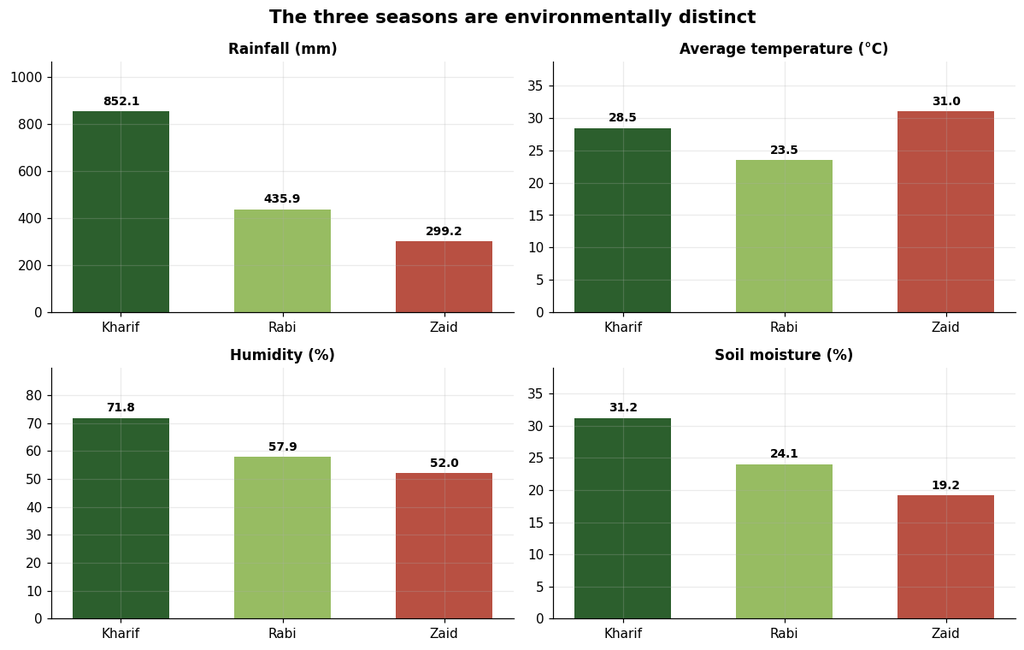

```python
fig, axes = plt.subplots(2, 2, figsize=(11, 7))

plots = [('Rainfall_mm', 'Rainfall (mm)'),
         ('Avg_Temperature_C', 'Average temperature (°C)'),
         ('Humidity_pct', 'Humidity (%)'),
         ('Soil_Moisture_pct', 'Soil moisture (%)')]

for ax, (col, label) in zip(axes.ravel(), plots):
    means = df_clean.groupby('Season', observed=True)[col].mean().reindex(SEASON_ORDER)
    bars = ax.bar(SEASON_ORDER, means.values,
                  color=[SEASON_COLORS[s] for s in SEASON_ORDER], width=0.6)
    ax.bar_label(bars, fmt='%.1f', padding=3, fontsize=9, fontweight='bold')
    ax.set_title(label, fontweight='bold', fontsize=11)
    ax.set_ylim(0, means.max() * 1.25)

fig.suptitle('The three seasons are environmentally distinct',
             fontsize=14, fontweight='bold')
plt.tight_layout()
plt.show()
```

```python
# Test each environmental variable for a season effect
print(f"{'Variable':<22}{'F-statistic':>13}{'p-value':>14}   Significant?")
print('-' * 65)

for col in env_cols:
    groups = [df_clean.loc[df_clean.Season == s, col] for s in SEASON_ORDER]
    f_stat, p_val = stats.f_oneway(*groups)
    flag = 'YES' if p_val < 0.05 else 'no'
    print(f'{col:<22}{f_stat:>13.2f}{p_val:>14.2e}   {flag}')
```

```
Variable                F-statistic       p-value   Significant?
-----------------------------------------------------------------
Rainfall_mm                 3448.57      0.00e+00   YES
Avg_Temperature_C           2678.74      0.00e+00   YES
Humidity_pct                1574.77      0.00e+00   YES
Sunlight_Hours               527.56     4.71e-204   YES
Soil_Moisture_pct           1642.87      0.00e+00   YES
Soil_pH                        3.07      4.64e-02   YES
```

**Finding.** The seasons form three sharply separated environmental regimes:

- **Kharif** — the monsoon season: 852 mm rainfall, 72% humidity, 31% soil moisture, least sunlight.
- **Rabi** — the cool winter season: 436 mm rainfall and the lowest temperature at 23.5 °C.
- **Zaid** — the hot dry summer: only 299 mm rainfall, the highest temperature at 31 °C, and soil moisture down to 19%.

## 4. Seasonal Yield Analysis

### 4.1 The pooled result — and why it misleads

```python
pooled = df_clean.groupby('Season', observed=True)['Yield_Tonnes_Hectare'].agg(
    ['mean', 'median', 'std', 'count']).round(2)
print(pooled)

groups = [df_clean.loc[df_clean.Season == s, 'Yield_Tonnes_Hectare'] for s in SEASON_ORDER]
f_stat, p_val = stats.f_oneway(*groups)
print(f'\nANOVA on pooled yield:  F = {f_stat:.2f},  p = {p_val:.4f}')
print('Conclusion:', 'significant' if p_val < 0.05 else 'NOT significant')
```

```
        mean  median    std  count
Season
Kharif  5.63    1.95  14.39   1779
Rabi    5.09    1.66  12.83   1627
Zaid    4.64    1.45  11.27    594

ANOVA on pooled yield:  F = 1.46,  p = 0.2328
Conclusion: NOT significant
```

Taken at face value, this says season has **no significant effect on yield** (p = 0.23). That contradicts both the environmental evidence above and basic agronomy — which is a strong hint that something is confounding the comparison.

The suspect is **crop mix**. Yield in tonnes per hectare is not comparable across crops: sugarcane yields tens of tonnes per hectare while pulses yield around one. If the seasons contain slightly different proportions of sugarcane, that single crop will swamp the seasonal signal.

```python
crop_yields = df_clean.groupby('Crop')['Yield_Tonnes_Hectare'].mean().sort_values(ascending=False)
print('Mean yield by crop (t/ha):')
print(crop_yields.round(2))

print('\nSugarcane share of farms in each season (%):')
share = (pd.crosstab(df_clean.Crop, df_clean.Season, normalize='columns') * 100)
print(share.loc['Sugarcane'].round(2))
```

```
Mean yield by crop (t/ha):
Crop
Sugarcane    46.93
Maize         2.72
Rice          2.44
Wheat         2.11
Chilli        1.54
Groundnut     1.32
Cotton        1.23
Pulses        0.92
Name: Yield_Tonnes_Hectare, dtype: float64

Sugarcane share of farms in each season (%):
Season
Kharif    7.03
Rabi      7.93
Zaid      8.59
Name: Sugarcane, dtype: float64
```

```python
# Repeat the ANOVA with sugarcane removed
no_cane = df_clean[df_clean.Crop != 'Sugarcane']
groups = [no_cane.loc[no_cane.Season == s, 'Yield_Tonnes_Hectare'] for s in SEASON_ORDER]
f_stat, p_val = stats.f_oneway(*groups)

print('Excluding sugarcane:')
print(no_cane.groupby('Season', observed=True)['Yield_Tonnes_Hectare'].mean().round(3))
print(f'\nANOVA:  F = {f_stat:.2f},  p = {p_val:.2e}')
print('Conclusion:', 'SIGNIFICANT' if p_val < 0.05 else 'not significant')
```

```
Excluding sugarcane:
Season
Kharif    2.016
Rabi      1.748
Zaid      1.464
Name: Yield_Tonnes_Hectare, dtype: float64

ANOVA:  F = 61.25,  p = 6.76e-27
Conclusion: SIGNIFICANT
```

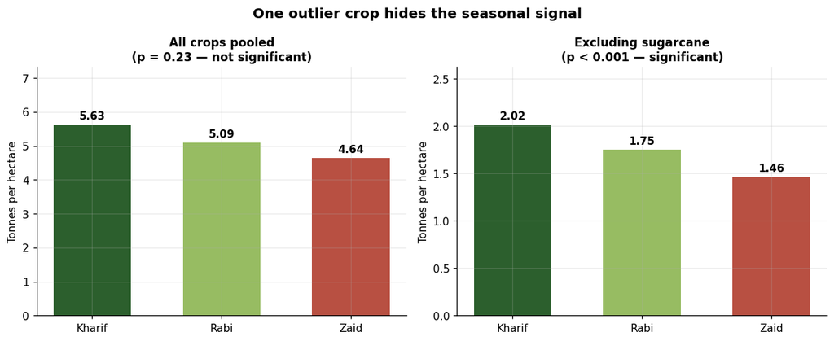

```python
fig, axes = plt.subplots(1, 2, figsize=(11, 4.5))

for ax, (data, title) in zip(axes, [
    (df_clean, 'All crops pooled\n(p = 0.23 — not significant)'),
    (no_cane,  'Excluding sugarcane\n(p < 0.001 — significant)')]):
    means = data.groupby('Season', observed=True)['Yield_Tonnes_Hectare'].mean().reindex(SEASON_ORDER)
    bars = ax.bar(SEASON_ORDER, means.values,
                  color=[SEASON_COLORS[s] for s in SEASON_ORDER], width=0.6)
    ax.bar_label(bars, fmt='%.2f', padding=3, fontweight='bold')
    ax.set_title(title, fontweight='bold', fontsize=11)
    ax.set_ylabel('Tonnes per hectare')
    ax.set_ylim(0, means.max() * 1.3)

fig.suptitle("One outlier crop hides the seasonal signal", fontsize=13, fontweight='bold')
plt.tight_layout()
plt.show()
```

**This is the most important methodological finding in the project.** Sugarcane makes up 7.0% of Kharif farms but 8.6% of Zaid farms. Because it yields roughly 20× more per hectare than any other crop, that 1.6 percentage-point difference is enough to cancel out a real decline happening in every other crop.

This is an instance of **Simpson's paradox** — an aggregate trend that reverses or vanishes once the data is correctly grouped. A generic whole-dataset analysis would have concluded "season does not affect yield", which is the opposite of the truth.

### 4.2 Within-crop analysis — the real seasonal pattern

```python
yield_pivot = df_clean.pivot_table(index='Crop', columns='Season',
                                   values='Yield_Tonnes_Hectare',
                                   aggfunc='mean', observed=True)[SEASON_ORDER]
print('Mean yield (t/ha) by crop and season:')
print(yield_pivot.round(2))

print('\nPer-crop ANOVA for a season effect:')
print(f"{'Crop':<12}{'F':>9}{'p-value':>12}   {'Kharif→Zaid drop':>18}")
print('-' * 55)

for crop in sorted(df_clean.Crop.unique()):
    sub = df_clean[df_clean.Crop == crop]
    groups = [sub.loc[sub.Season == s, 'Yield_Tonnes_Hectare'] for s in SEASON_ORDER]
    f_stat, p_val = stats.f_oneway(*groups)
    drop = (groups[0].mean() - groups[2].mean()) / groups[0].mean() * 100
    print(f'{crop:<12}{f_stat:>9.2f}{p_val:>12.2e}   {drop:>17.1f}%')
```

```
Mean yield (t/ha) by crop and season:
Season     Kharif   Rabi   Zaid
Crop
Chilli       1.73   1.46   1.18
Cotton       1.37   1.19   0.95
Groundnut    1.48   1.22   1.04
Maize        2.97   2.62   2.30
Pulses       1.04   0.87   0.65
Rice         2.71   2.33   1.90
Sugarcane   53.46  43.96  38.42
Wheat        2.26   2.06   1.75

Per-crop ANOVA for a season effect:
Crop                F     p-value     Kharif→Zaid drop
-------------------------------------------------------
Chilli          14.03    1.27e-06                31.9%
Cotton          23.42    1.87e-10                30.7%
Groundnut       16.37    1.42e-07                30.1%
Maize           10.80    2.51e-05                22.6%
Pulses          24.11    1.02e-10                37.0%
Rice            22.63    3.03e-10                29.9%
Sugarcane       12.35    6.99e-06                28.1%
Wheat           11.09    1.87e-05                22.5%
```

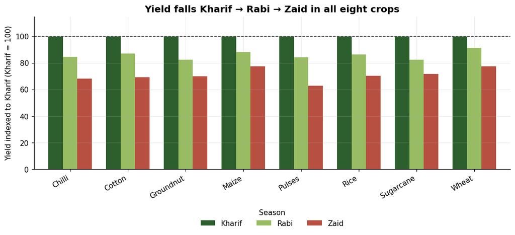

```python
# Index each crop to its own Kharif yield so all crops sit on one scale
indexed = yield_pivot.div(yield_pivot['Kharif'], axis=0) * 100

fig, ax = plt.subplots(figsize=(10, 5))
indexed.plot(kind='bar', ax=ax,
             color=[SEASON_COLORS[s] for s in SEASON_ORDER],
             width=0.75, edgecolor='none')
ax.axhline(100, ls='--', lw=1, color='#444')
ax.set_ylabel('Yield indexed to Kharif (Kharif = 100)')
ax.set_xlabel('')
ax.set_ylim(0, 115)
ax.set_title('Yield falls Kharif → Rabi → Zaid in all eight crops',
             fontsize=13, fontweight='bold')
ax.legend(title='Season', frameon=False, ncol=3,
          loc='lower center', bbox_to_anchor=(0.5, -0.42))
plt.xticks(rotation=30, ha='right')
plt.tight_layout()
plt.show()
```

**Finding.** Once crop is held constant, the pattern is unambiguous and universal: **every one of the eight crops yields most in Kharif, less in Rabi, and least in Zaid**, and the effect is statistically significant for each crop individually (all p < 0.001).

The decline from Kharif to Zaid ranges from **22.5% (wheat)** to **37.0% (pulses)**. Pulses, cotton, chilli and groundnut are the most seasonally sensitive; wheat and maize are the most resilient.

### 4.3 What drives yield within a season?

```python
predictors = ['Rainfall_mm', 'Avg_Temperature_C', 'Humidity_pct', 'Sunlight_Hours',
              'Soil_pH', 'Soil_Moisture_pct', 'Nitrogen_kg_ha', 'Phosphorus_kg_ha',
              'Potassium_kg_ha', 'Fertilizer_kg_ha', 'Pesticide_Litre_ha',
              'Water_Used_m3', 'Seed_Quality_Score', 'Farm_Area_Hectares',
              'Disease_Pest_Risk_pct']

corr_table = pd.DataFrame({
    season: (df_clean[df_clean.Season == season][predictors + ['Yield_Tonnes_Hectare']]
             .corr()['Yield_Tonnes_Hectare'].drop('Yield_Tonnes_Hectare'))
    for season in SEASON_ORDER
}).round(3)

corr_table.sort_values('Kharif', key=abs, ascending=False)
```

|  | Kharif | Rabi | Zaid |
| --- | --- | --- | --- |
| Water_Used_m3 | 0.357 | 0.425 | 0.405 |
| Phosphorus_kg_ha | 0.051 | 0.038 | 0.059 |
| Nitrogen_kg_ha | 0.048 | 0.074 | 0.017 |
| Disease_Pest_Risk_pct | -0.027 | 0.013 | 0.039 |
| Farm_Area_Hectares | 0.026 | 0.037 | 0.030 |
| Soil_pH | -0.026 | -0.019 | -0.024 |
| Sunlight_Hours | -0.021 | 0.009 | 0.023 |
| Seed_Quality_Score | -0.019 | 0.005 | -0.002 |
| Rainfall_mm | -0.019 | 0.037 | 0.047 |
| Humidity_pct | -0.016 | 0.016 | -0.061 |
| Fertilizer_kg_ha | -0.014 | 0.013 | 0.007 |
| Avg_Temperature_C | -0.011 | 0.057 | -0.044 |
| Potassium_kg_ha | -0.002 | 0.010 | 0.013 |
| Soil_Moisture_pct | 0.001 | -0.020 | -0.030 |
| Pesticide_Litre_ha | 0.000 | -0.013 | -0.028 |

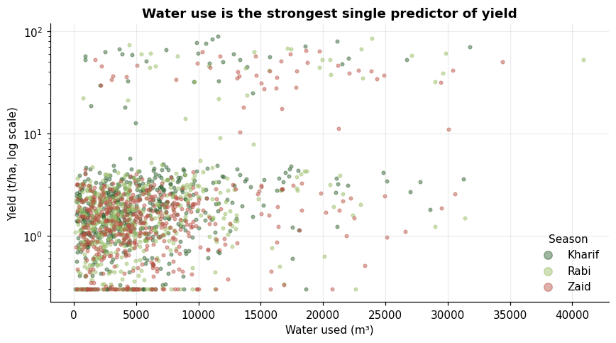

```python
fig, ax = plt.subplots(figsize=(8, 4.5))

for season in SEASON_ORDER:
    sub = df_clean[df_clean.Season == season].sample(500, random_state=1)
    ax.scatter(sub.Water_Used_m3, sub.Yield_Tonnes_Hectare,
               s=9, alpha=0.45, color=SEASON_COLORS[season], label=season)

ax.set_yscale('log')
ax.set_xlabel('Water used (m³)')
ax.set_ylabel('Yield (t/ha, log scale)')
ax.set_title('Water use is the strongest single predictor of yield',
             fontsize=12, fontweight='bold')
ax.legend(title='Season', frameon=False, markerscale=2.5)
plt.tight_layout()
plt.show()
```

**Finding.** In all three seasons, **water used is by far the strongest correlate of yield** (r = 0.36 in Kharif, 0.43 in Rabi, 0.41 in Zaid). Every other variable — fertiliser, nitrogen, seed quality, soil pH — correlates at |r| < 0.08, which is effectively noise at this sample size.

Notice that the water–yield relationship is *strongest in Rabi and Zaid*, the two dry seasons. When rain is scarce, irrigation becomes the binding constraint on output — which makes the choice of irrigation method (Section 6) a seasonal decision, not a fixed one.

## 5. Economic Performance Across Seasons

```python
econ_cols = ['Total_Cost_INR', 'Revenue_INR', 'Profit_INR', 'Profit_per_Hectare']
econ = df_clean.groupby('Season', observed=True)[econ_cols].mean().round(0)
econ['Profitable_farms_pct'] = (df_clean.groupby('Season', observed=True)['Is_Profitable']
                                .mean() * 100).round(1)
econ
```

| Season | Total_Cost_INR | Revenue_INR | Profit_INR | Profit_per_Hectare | Profitable_farms_pct |
| --- | --- | --- | --- | --- | --- |
| Kharif | 531804.0 | 710719.0 | 178915.0 | 21882.0 | 57.8 |
| Rabi | 513837.0 | 601526.0 | 87689.0 | 10362.0 | 48.9 |
| Zaid | 543977.0 | 519172.0 | -24805.0 | -2637.0 | 35.5 |

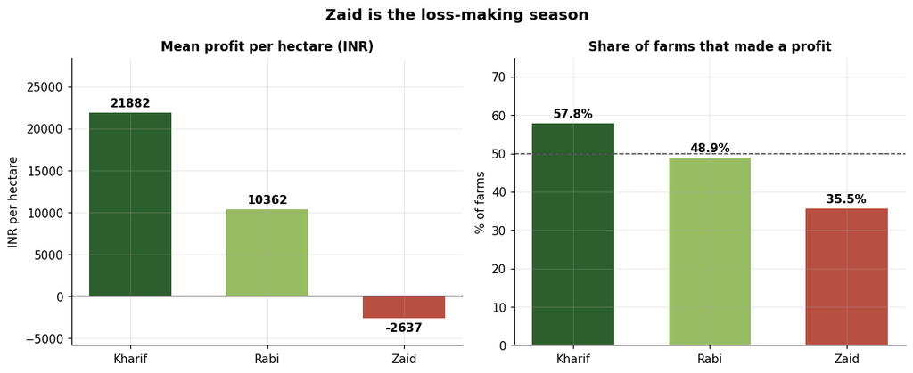

```python
fig, axes = plt.subplots(1, 2, figsize=(11, 4.5))

means = df_clean.groupby('Season', observed=True)['Profit_per_Hectare'].mean().reindex(SEASON_ORDER)
bars = axes[0].bar(SEASON_ORDER, means.values,
                   color=[SEASON_COLORS[s] for s in SEASON_ORDER], width=0.6)
axes[0].bar_label(bars, fmt='%.0f', padding=3, fontweight='bold')
axes[0].axhline(0, color='#333', lw=1)
axes[0].set_title('Mean profit per hectare (INR)', fontweight='bold', fontsize=11)
axes[0].set_ylabel('INR per hectare')
axes[0].set_ylim(means.min() * 2.2, means.max() * 1.3)

rate = (df_clean.groupby('Season', observed=True)['Is_Profitable'].mean() * 100).reindex(SEASON_ORDER)
bars = axes[1].bar(SEASON_ORDER, rate.values,
                   color=[SEASON_COLORS[s] for s in SEASON_ORDER], width=0.6)
axes[1].bar_label(bars, fmt='%.1f%%', padding=3, fontweight='bold')
axes[1].axhline(50, ls='--', lw=1, color='#444')
axes[1].set_title('Share of farms that made a profit', fontweight='bold', fontsize=11)
axes[1].set_ylabel('% of farms')
axes[1].set_ylim(0, 75)

fig.suptitle('Zaid is the loss-making season', fontsize=13, fontweight='bold')
plt.tight_layout()
plt.show()
```

```python
print('Pairwise comparison of profit per hectare (Welch t-test):')
print(f"{'Comparison':<22}{'t':>9}{'p-value':>13}   Significant?")
print('-' * 60)

for a, b in [('Kharif', 'Rabi'), ('Kharif', 'Zaid'), ('Rabi', 'Zaid')]:
    t_stat, p_val = stats.ttest_ind(
        df_clean.loc[df_clean.Season == a, 'Profit_per_Hectare'],
        df_clean.loc[df_clean.Season == b, 'Profit_per_Hectare'],
        equal_var=False)
    flag = 'YES' if p_val < 0.05 else 'no'
    print(f'{a} vs {b:<12}{t_stat:>9.2f}{p_val:>13.2e}   {flag}')
```

```
Pairwise comparison of profit per hectare (Welch t-test):
Comparison                    t      p-value   Significant?
------------------------------------------------------------
Kharif vs Rabi             5.61     2.19e-08   YES
Kharif vs Zaid            10.17     1.63e-23   YES
Rabi vs Zaid             5.65     2.00e-08   YES
```

### 5.1 Why does profit collapse? Cost or revenue?

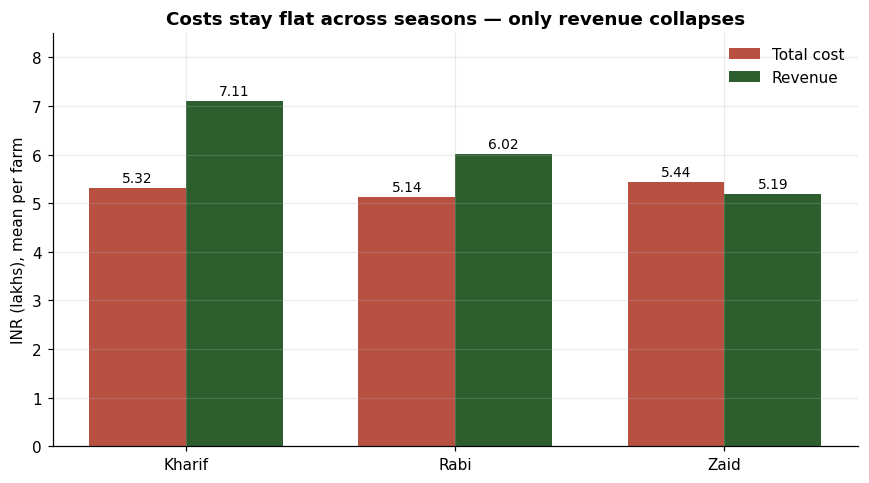

```
Season-to-season change vs Kharif:
        cost_change_pct  revenue_change_pct
Season
Kharif              0.0                 0.0
Rabi               -3.4               -15.4
Zaid                2.3               -27.0
```

```python
fig, ax = plt.subplots(figsize=(8, 4.5))

x = np.arange(3)
width = 0.36
cost = df_clean.groupby('Season', observed=True)['Total_Cost_INR'].mean().reindex(SEASON_ORDER) / 1e5
rev  = df_clean.groupby('Season', observed=True)['Revenue_INR'].mean().reindex(SEASON_ORDER) / 1e5

b1 = ax.bar(x - width/2, cost.values, width, label='Total cost', color='#B85042')
b2 = ax.bar(x + width/2, rev.values,  width, label='Revenue',    color='#2C5F2D')
ax.bar_label(b1, fmt='%.2f', padding=2, fontsize=9)
ax.bar_label(b2, fmt='%.2f', padding=2, fontsize=9)

ax.set_xticks(x)
ax.set_xticklabels(SEASON_ORDER)
ax.set_ylabel('INR (lakhs), mean per farm')
ax.set_title('Costs stay flat across seasons — only revenue collapses',
             fontsize=12, fontweight='bold')
ax.legend(frameon=False)
ax.set_ylim(0, 8.5)
plt.tight_layout()
plt.show()

print('Season-to-season change vs Kharif:')
print(pd.DataFrame({
    'cost_change_pct': ((cost / cost['Kharif'] - 1) * 100).round(1),
    'revenue_change_pct': ((rev / rev['Kharif'] - 1) * 100).round(1),
}))
```

```python
# Is the revenue fall caused by price, or by volume?
price = df_clean.pivot_table(index='Crop', columns='Season',
                             values='Market_Price_INR', aggfunc='mean', observed=True)[SEASON_ORDER]
print('Mean market price per crop (INR):')
print(price.round(0))

print('\nMax price variation across seasons, per crop:')
variation = ((price.max(axis=1) - price.min(axis=1)) / price.mean(axis=1) * 100).round(2)
print(variation.sort_values(ascending=False))
```

```
Mean market price per crop (INR):
Season       Kharif      Rabi      Zaid
Crop
Chilli     103409.0  104338.0  100810.0
Cotton      68591.0   67477.0   67325.0
Groundnut   56611.0   56261.0   55395.0
Maize       20878.0   20997.0   21285.0
Pulses      71726.0   71276.0   70918.0
Rice        21924.0   22116.0   22078.0
Sugarcane    3476.0    3487.0    3534.0
Wheat       23734.0   24021.0   23622.0

Max price variation across seasons, per crop:
Crop
Chilli       3.43
Groundnut    2.17
Maize        1.93
Cotton       1.87
Wheat        1.68
Sugarcane    1.64
Pulses       1.13
Rice         0.87
dtype: float64
```

**Finding.** The economic gradient is steep and statistically significant at every step (all pairwise p < 0.001):

| Season | Profit / hectare | Farms in profit |
| --- | --- | --- |
| Kharif | **₹21,882** | 57.8% |
| Rabi | **₹10,362** | 48.9% |
| Zaid | **−₹2,637** | 35.5% |

The mechanism is clear once cost and revenue are separated. **Costs barely move** — Zaid actually costs 2.3% *more* than Kharif, since dry conditions demand more irrigation. Meanwhile **revenue falls 27%** from Kharif to Zaid.

And that revenue fall is not a price effect: market prices vary by less than 3.5% across seasons for every crop. It is purely a **volume effect** — the same yield decline documented in Section 4.2, flowing straight through to the bottom line. Farmers pay roughly the same to produce substantially less.

## 6. Risk and Resource Use

### 6.1 Disease and pest pressure

```python
risk = df_clean.groupby('Season', observed=True)['Disease_Pest_Risk_pct'].agg(
    ['mean', 'std']).round(2)
print(risk)

groups = [df_clean.loc[df_clean.Season == s, 'Disease_Pest_Risk_pct'] for s in SEASON_ORDER]
f_stat, p_val = stats.f_oneway(*groups)
print(f'\nANOVA:  F = {f_stat:.2f},  p = {p_val:.2e}')

print('\nCorrelation of disease risk with environmental drivers:')
for col in ['Rainfall_mm', 'Humidity_pct', 'Soil_Moisture_pct', 'Avg_Temperature_C']:
    r = df_clean['Disease_Pest_Risk_pct'].corr(df_clean[col])
    print(f'  {col:22s} r = {r:+.3f}')
```

```
         mean    std
Season
Kharif  54.47  10.09
Rabi    40.48  10.10
Zaid    38.22   9.87

ANOVA:  F = 1049.47,  p = 0.00e+00

Correlation of disease risk with environmental drivers:
  Rainfall_mm            r = +0.624
  Humidity_pct           r = +0.545
  Soil_Moisture_pct      r = +0.379
  Avg_Temperature_C      r = +0.246
```

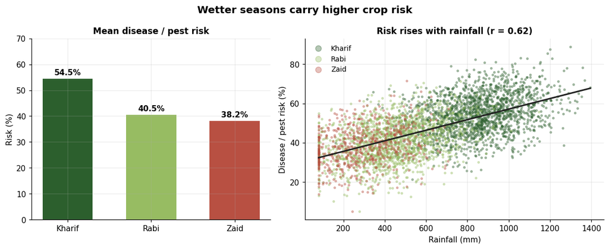

```python
fig, axes = plt.subplots(1, 2, figsize=(11, 4.5),
                         gridspec_kw={'width_ratios': [1, 1.25]})

means = df_clean.groupby('Season', observed=True)['Disease_Pest_Risk_pct'].mean().reindex(SEASON_ORDER)
bars = axes[0].bar(SEASON_ORDER, means.values,
                   color=[SEASON_COLORS[s] for s in SEASON_ORDER], width=0.6)
axes[0].bar_label(bars, fmt='%.1f%%', padding=3, fontweight='bold')
axes[0].set_title('Mean disease / pest risk', fontweight='bold', fontsize=11)
axes[0].set_ylabel('Risk (%)')
axes[0].set_ylim(0, 70)

for season in SEASON_ORDER:
    sub = df_clean[df_clean.Season == season]
    axes[1].scatter(sub.Rainfall_mm, sub.Disease_Pest_Risk_pct,
                    s=6, alpha=0.35, color=SEASON_COLORS[season], label=season)

fit = np.polyfit(df_clean.Rainfall_mm, df_clean.Disease_Pest_Risk_pct, 1)
xs = np.linspace(df_clean.Rainfall_mm.min(), df_clean.Rainfall_mm.max(), 50)
axes[1].plot(xs, np.polyval(fit, xs), color='#222', lw=2)
axes[1].set_xlabel('Rainfall (mm)')
axes[1].set_ylabel('Disease / pest risk (%)')
axes[1].set_title('Risk rises with rainfall (r = 0.62)', fontweight='bold', fontsize=11)
axes[1].legend(frameon=False, markerscale=3, fontsize=9)

fig.suptitle('Wetter seasons carry higher crop risk', fontsize=13, fontweight='bold')
plt.tight_layout()
plt.show()
```

**Finding — and an important trade-off.** Disease and pest risk runs at **54.5% in Kharif** against **38.2% in Zaid** (p < 0.001), and tracks rainfall (r = +0.62) and humidity (r = +0.55) closely.

This produces the project's central tension: **Kharif is simultaneously the most profitable and the riskiest season.** The monsoon moisture that drives high yields is the same moisture that breeds pathogens and pests. Kharif's advantage is therefore real but conditional — it holds *provided* crop protection is managed. Notably, recorded pesticide use is essentially flat across seasons (5.08 / 5.02 / 5.17 litres per hectare), meaning input intensity is **not** being adjusted to match the risk profile of the season.

### 6.2 Does the best irrigation method depend on the season?

```python
print('Irrigation method mix by season (% of farms):')
mix = pd.crosstab(df_clean.Irrigation_Method, df_clean.Season, normalize='columns') * 100
print(mix.round(1))

chi2, p_val, dof, _ = stats.chi2_contingency(
    pd.crosstab(df_clean.Irrigation_Method, df_clean.Season))
print(f'\nChi-square test of independence:  chi2 = {chi2:.2f},  p = {p_val:.3f}')
print('Interpretation:', 'method choice depends on season'
      if p_val < 0.05 else 'method choice is INDEPENDENT of season')
```

```
Irrigation method mix by season (% of farms):
Season             Kharif  Rabi  Zaid
Irrigation_Method
Drip                 22.8  22.7  23.6
Flood                33.2  32.3  32.7
Rainfed              26.0  26.9  23.6
Sprinkler            18.0  18.0  20.2

Chi-square test of independence:  chi2 = 3.51,  p = 0.742
Interpretation: method choice is INDEPENDENT of season
```

```python
eff = df_clean.pivot_table(index='Irrigation_Method', columns='Season',
                           values='Water_Efficiency', aggfunc='mean', observed=True)[SEASON_ORDER]
prof = df_clean.pivot_table(index='Irrigation_Method', columns='Season',
                            values='Profit_per_Hectare', aggfunc='mean', observed=True)[SEASON_ORDER]

print('Water efficiency by method and season:')
print(eff.round(2))
print('\nProfit per hectare by method and season (INR):')
print(prof.round(0))
```

```
Water efficiency by method and season:
Season             Kharif  Rabi  Zaid
Irrigation_Method
Drip                 6.80  6.05  5.30
Flood                3.64  3.48  2.73
Rainfed              8.85  6.87  5.48
Sprinkler            4.62  4.64  4.86

Profit per hectare by method and season (INR):
Season              Kharif     Rabi    Zaid
Irrigation_Method
Drip               36259.0  22676.0  2540.0
Flood              16607.0   6809.0 -8937.0
Rainfed            18087.0   6450.0 -9498.0
Sprinkler          18912.0   7036.0  9515.0
```

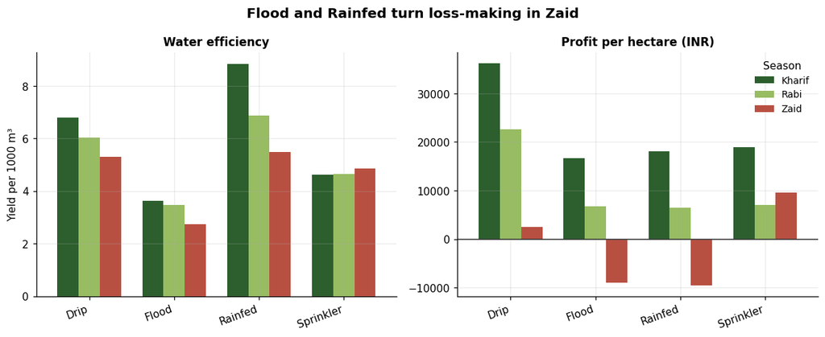

```python
fig, axes = plt.subplots(1, 2, figsize=(11, 4.5))

eff.plot(kind='bar', ax=axes[0],
         color=[SEASON_COLORS[s] for s in SEASON_ORDER], width=0.75, legend=False)
axes[0].set_title('Water efficiency', fontweight='bold', fontsize=11)
axes[0].set_ylabel('Yield per 1000 m³')
axes[0].set_xlabel('')

prof.plot(kind='bar', ax=axes[1],
          color=[SEASON_COLORS[s] for s in SEASON_ORDER], width=0.75)
axes[1].axhline(0, color='#333', lw=1)
axes[1].set_title('Profit per hectare (INR)', fontweight='bold', fontsize=11)
axes[1].set_xlabel('')
axes[1].legend(title='Season', frameon=False, fontsize=9)

for ax in axes:
    plt.setp(ax.get_xticklabels(), rotation=20, ha='right')

fig.suptitle('Flood and Rainfed turn loss-making in Zaid', fontsize=13, fontweight='bold')
plt.tight_layout()
plt.show()
```

**Finding — the clearest actionable result in the project.** The chi-square test shows irrigation method is chosen **independently of season** (p = 0.74): farmers use roughly the same mix of Drip, Flood, Rainfed and Sprinkler regardless of whether it is monsoon or peak summer. But the outcomes are emphatically *not* season-independent:

| Method | Kharif profit/ha | Zaid profit/ha |
| --- | --- | --- |
| **Drip** | ₹36,259 | **+₹2,540** |
| Sprinkler | ₹18,912 | +₹9,515 |
| Flood | ₹16,607 | **−₹8,937** |
| Rainfed | ₹18,087 | **−₹9,498** |

In Kharif every method turns a profit and the choice is not critical. In Zaid, **Flood and Rainfed swing to heavy losses while Drip and Sprinkler stay positive**. Rainfed's collapse is intuitive — there is no rain to depend on. Flood's is more damaging: it consumes the most water of any method (8,114 m³ in Zaid) at the worst efficiency (2.73), burning irrigation cost without converting it into yield.

**The gap between a season-independent decision and a season-dependent outcome is where the losses in this dataset come from.**